# Practical Machine Learning Course Project V2

Yue Hou

July 2, 2017

# project description

Use the “pml-training” dataset to predict the manner how 6 participants exercise. I split the training data (19622 observations) into 60% of train (11776 samples), 20% of validation (3923) and 20% of test (3923). And used validation set for model selection and parameter tuning, at last used test set to calculate the out of sample error (accuracy for this multi-class classification problem).

first I cleaned and explored the train data set by removing the NA columns and calculating the correlation among pairs of predictors. There are 20 pairs with high correlations, so I tried PCA in my modeling methods.

Second, I did the same preprocessing with validation data set (removing NAs). Then I tried 3 models (classificaiton tree, svm and boosting). Since this is a classification problem, so I didn’t choose any regression models. For the classification tree and svm, the accuracy on validation set is poor, so I also tried PCA on these two methods, but no significant improvement. By comparing the 5 methods (tree +/- PCA, svm +/- PCA, boosting) on validation, I decided to choose boosting (gbm) model, because it’s the most accurate. (Actually, I also tried random forest in my R script, but it was too slow, and cause a problem for me to compile to Html, so later I delete this model. Random forest is a little bit accurate than boosting.)

Third, I tried to interpret the prediction variables, so I compared the variance importance rank for each method, and plot some scatter and box plot for them vs. output “classe”.

Finally, I used the test set (3923 samples, not the “pml-testing” 20 samples for the quiz) to calculate the out of sample error.

# Codes

set up working directory open the installed [easypackages] library, which can install and open multiple packages simutaneously.

load all needed packages [ggplot2], [corrplot], [gridExtra], [caret] using [easypackages]

```r
# setwd("C:/Courses/Practicle ML in R caret")
library(easypackages)
```

```r
libraries("ggplot2", "corrplot", "gridExtra", "Hmisc", "caTools", "caret", "gbm", "randomForest")
```

```
## All packages loaded successfully
```

# 1. Data Cleaning and Exloration

load the training and testing data

```r
training <- read.csv("C:/Courses/Practicle ML in R caret/practicalmachinelearning/pml-training.csv")
testing <- read.csv("C:/Courses/Practicle ML in R caret/practicalmachinelearning/pml-testing.csv")
```

## split the training data into train_data (60%), validation_data (20%) and test_data (20%)

set seed for reproducibility

first split training into train (60%) and inBuild (40%), then split inBuild into validation (20%) and test (20%)

```r
set.seed(1234)
train_index <- createDataPartition(training$classe, p = 0.6, list = FALSE)
train_data <- training[train_index, ]   # train data set
inBuild_data <- training[-train_index, ]
validation_index <- createDataPartition(inBuild_data$classe, p = 0.5, list = FALSE)
validation_data <- inBuild_data[validation_index, ]   # validation data set
test_data <- inBuild_data[-validation_index, ]        # test data set
```

```r
dim(train_data); dim(validation_data); dim(test_data)
```

```
## [1] 11776   160
```

```
## [1] 3923  160
```

```
## [1] 3923  160
```

```r
str(train_data[, 1:20])
```

```
## 'data.frame':    11776 obs. of  20 variables:
##  $ X                   : int  2 3 4 5 6 7 8 10 11 12 ...
##  $ user_name           : Factor w/ 6 levels "adelmo","carlitos",..: 2 2 2 2 2 2 2 2 2 2 ...
##  $ raw_timestamp_part_1: int  1323084231 1323084231 1323084232 1323084232 1323084232 1323084232 1323084232 1323084232 1323084232 1323084232 ...
##  $ raw_timestamp_part_2: int  808298 820366 120339 196328 304277 368296 440390 484434 500302 528316 ...
##  $ cvtd_timestamp      : Factor w/ 20 levels "02/12/2011 13:32",..: 9 9 9 9 9 9 9 9 9 9 ...
##  $ new_window          : Factor w/ 2 levels "no","yes": 1 1 1 1 1 1 1 1 1 1 ...
##  $ num_window          : int  11 11 12 12 12 12 12 12 12 12 ...
##  $ roll_belt           : num  1.41 1.42 1.48 1.48 1.45 1.42 1.42 1.45 1.45 1.43 ...
##  $ pitch_belt          : num  8.07 8.07 8.05 8.07 8.06 8.09 8.13 8.17 8.18 8.18 ...
##  $ yaw_belt            : num  -94.4 -94.4 -94.4 -94.4 -94.4 -94.4 -94.4 -94.4 -94.4 -94.4 ...
##  $ total_accel_belt    : int  3 3 3 3 3 3 3 3 3 3 ...
##  $ kurtosis_roll_belt  : Factor w/ 397 levels "","-0.016850",..: 1 1 1 1 1 1 1 1 1 1 ...
##  $ kurtosis_picth_belt : Factor w/ 317 levels "","-0.021887",..: 1 1 1 1 1 1 1 1 1 1 ...
##  $ kurtosis_yaw_belt   : Factor w/ 2 levels "","#DIV/0!": 1 1 1 1 1 1 1 1 1 1 ...
##  $ skewness_roll_belt  : Factor w/ 395 levels "","-0.003095",..: 1 1 1 1 1 1 1 1 1 1 ...
##  $ skewness_roll_belt.1: Factor w/ 338 levels "","-0.005928",..: 1 1 1 1 1 1 1 1 1 1 ...
##  $ skewness_yaw_belt   : Factor w/ 2 levels "","#DIV/0!": 1 1 1 1 1 1 1 1 1 1 ...
##  $ max_roll_belt       : num  NA NA NA NA NA NA NA NA NA NA ...
##  $ max_picth_belt      : int  NA NA NA NA NA NA NA NA NA NA ...
##  $ max_yaw_belt        : Factor w/ 68 levels "","-0.1","-0.2",..: 1 1 1 1 1 1 1 1 1 1 ...
```

**wragling train_data**

There are lots of missing data/NAs, so find all the predictors with NA or blank and then remove them from train_data.

create a substitude train_data2 and do cleaning on train_data2

```r
train_data2 <- train_data
train_data2[train_data2 == c("", " ")] <- NA
train_data2 <- train_data2[, colSums(is.na(train_data2)) == 0]  # delete all columns with "NA"
```

```r
prop.table(table(train_data$classe))
```

```
##
##         A         B         C         D         E
## 0.2843071 0.1935292 0.1744226 0.1638927 0.1838485
```

explorating train_data2: the predictors structure/class, distribution/frequency

```r
# str(train_data2)
summary(train_data2[, 1:10])
```

```
##        X            user_name    raw_timestamp_part_1 raw_timestamp_part_2
##  Min.   :    2   adelmo  :2327   Min.   :1.322e+09    Min.   :   294
##  1st Qu.: 4936   carlitos:1881   1st Qu.:1.323e+09    1st Qu.:258646
##  Median : 9794   charles :2147   Median :1.323e+09    Median :496316
##  Mean   : 9808   eurico  :1878   Mean   :1.323e+09    Mean   :501632
##  3rd Qu.:14708   jeremy  :1985   3rd Qu.:1.323e+09    3rd Qu.:752363
##  Max.   :19621   pedro   :1558   Max.   :1.323e+09    Max.   :998750
##
##           cvtd_timestamp new_window    num_window    roll_belt
##  05/12/2011 11:24: 904   no :11540   Min.   :  1   Min.   :-28.90
##  28/11/2011 14:14: 898   yes:  236   1st Qu.:221   1st Qu.:  1.11
##  05/12/2011 11:25: 860               Median :421   Median :114.00
##  30/11/2011 17:11: 857               Mean   :430   Mean   : 64.50
##  02/12/2011 14:57: 846               3rd Qu.:644   3rd Qu.:123.00
##  05/12/2011 14:23: 828               Max.   :864   Max.   :162.00
##  (Other)         :6583
##    pitch_belt          yaw_belt
##  Min.   :-55.8000   Min.   :-179.00
##  1st Qu.:  1.8275   1st Qu.: -88.30
##  Median :  5.2900   Median : -12.60
##  Mean   :  0.3029   Mean   : -11.15
##  3rd Qu.: 15.0000   3rd Qu.:  13.10
##  Max.   : 60.3000   Max.   : 179.00
##
```

col 3 and 7 looks weired, they have lots of same values. Draw boxplot of them vs. output “classe”

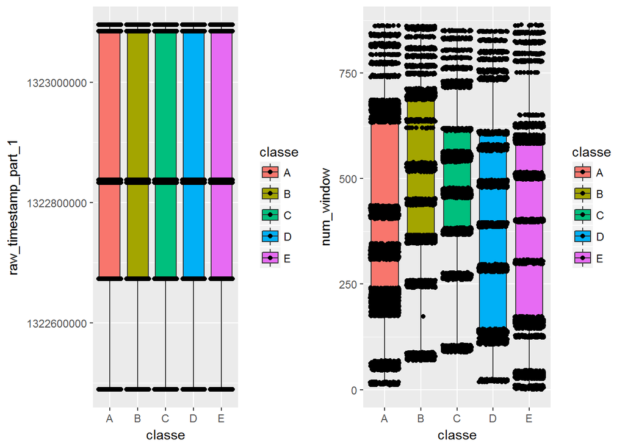

```r
p1 <- qplot(classe, raw_timestamp_part_1, data = train_data2, fill = classe,
            geom = c("boxplot", "jitter"))
p2 <- qplot(classe, num_window, data = train_data2, fill = classe,
            geom = c("boxplot", "jitter"))
grid.arrange(p1, p2, ncol = 2)
```

raw_timestamp_part_1 and num_window looks like a steped increasing data, so keep them.

col 1 “X” is just row index, so delete it.

check the correlation among only numeric variables (from str(train_data2) result, I know that columns 1, 4, 5 and 59 are factor variables.)

select pairs with high correlation (larger than 0.8)

```r
train_data2 <- train_data2[, -1]
corr_mat <- abs(cor(train_data2[ , c(2,3,6:58)]))
diag(corr_mat) <- 0   # make diagnal self-correlation as 0
corr_pairs <- which(corr_mat > 0.8, arr.ind = T)
```

```r
length(corr_pairs)
```

```
## [1] 80
```

# 2. Modeling and Comparing between models

first select the undeleted predictors’ index in train_data2, by finding the matched colnames between validation_data and train_data2.

```r
match_index <- colnames(validation_data) %in% colnames(train_data2)
validation_data2 <- validation_data[, match_index]
```

```r
dim(validation_data2)
```

```
## [1] 3923   59
```

## **then set the trainControl, using 5-fold cross-validation, ‘center’ and ‘scale’ preprocess for all models/methods**

**1. svm model with Radial Basis Function Kernel** set seed for reproducibility

Then prediction on validation set, and calculate performance/accuracy on validation set

```r
# library(caret)
fitControl <- trainControl(method="cv", number = 5, classProbs = TRUE)
set.seed(333)
# # rf model, cause a problem for compiling, so delete it from the report.
# model_rf <- train(classe ~.,
#                   train_data2,
#                   method = "rf",
#                   preProcess = c('center', 'scale'),
#                   prox = TRUE,
#                   trControl = fitControl)
# pred_rf <- predict(model_rf, validation_data2)
# cm_rf <- confusionMatrix(pred_rf, validation_data2$classe)

# svm
model_svm <- train(classe ~.,
                  train_data2,
                  method = "svmRadial",
                  preProcess = c('center', 'scale'),
                  # prox = TRUE,
                  trControl = fitControl)
# prediction
pred_svm <- predict(model_svm, validation_data2)
# performance
cm_svm <- confusionMatrix(pred_svm, validation_data2$classe)
cm_svm
```

```
## Confusion Matrix and Statistics
##
##           Reference
## Prediction    A    B    C    D    E
##          A 1101   58   62    0    0
##          B   15  652  220   25    0
##          C    0   49  295   89    2
##          D    0    0  107  454   13
##          E    0    0    0   75  706
##
## Overall Statistics
##
##                Accuracy : 0.8177
##                  95% CI : (0.8053, 0.8297)
##     No Information Rate : 0.2845
##     P-Value [Acc > NIR] : < 2.2e-16
##
##                   Kappa : 0.7683
##  Mcnemar's Test P-Value : NA
##
## Statistics by Class:
##
##                      Class: A Class: B Class: C Class: D Class: E
## Sensitivity            0.9866   0.8590   0.4313   0.7061   0.9792
## Specificity            0.9572   0.9178   0.9568   0.9634   0.9766
## Pos Pred Value         0.9017   0.7149   0.6782   0.7909   0.9040
## Neg Pred Value         0.9944   0.9645   0.8885   0.9436   0.9952
## Prevalence             0.2845   0.1935   0.1744   0.1639   0.1838
## Detection Rate         0.2807   0.1662   0.0752   0.1157   0.1800
## Detection Prevalence   0.3112   0.2325   0.1109   0.1463   0.1991
## Balanced Accuracy      0.9719   0.8884   0.6940   0.8347   0.9779
```

## svm is 2nd accurate model, and the 3rd fast model.

**2. svm model with PCA** PCA components for train and validation set to capture 90% variance

```r
preProc <- preProcess(train_data2[, -59], method = "pca", thresh = 0.9)
trainPCA <- predict(preProc, train_data2[, -59])
trainPCA$classe <- train_data2$classe
validationPCA <- predict(preProc, validation_data2[, -59])
validationPCA$classe <- validation_data2$classe
# svm_pca
model_svm_pca <- train(classe ~.,
                       trainPCA,
                       method = "svmRadial",
                       preProcess = c('center', 'scale'),
                       trControl = fitControl)
# prediction and performance
pred_svm_pca <- predict(model_svm_pca, validationPCA)
cm_svm_pca <- confusionMatrix(pred_svm_pca, validationPCA$classe)
```

```r
preProc
```

```
## Created from 11776 samples and 58 variables
##
## Pre-processing:
##   - centered (55)
##   - ignored (3)
##   - principal component signal extraction (55)
##   - scaled (55)
##
## PCA needed 20 components to capture 90 percent of the variance
```

```r
dim(trainPCA); dim(validationPCA)
```

```
## [1] 11776    24
```

```
## [1] 3923   24
```

```r
cm_svm_pca
```

```
## Confusion Matrix and Statistics
##
##           Reference
## Prediction    A    B    C    D    E
##          A 1075   90  119    0    0
##          B   39  600  175   20    0
##          C    2   69  263   73    2
##          D    0    0  127  471   19
##          E    0    0    0   79  700
##
## Overall Statistics
##
##                Accuracy : 0.7925
##                  95% CI : (0.7795, 0.8051)
##     No Information Rate : 0.2845
##     P-Value [Acc > NIR] : < 2.2e-16
##
##                   Kappa : 0.7358
##  Mcnemar's Test P-Value : NA
##
## Statistics by Class:
##
##                      Class: A Class: B Class: C Class: D Class: E
## Sensitivity            0.9633   0.7905  0.38450   0.7325   0.9709
## Specificity            0.9255   0.9260  0.95492   0.9555   0.9753
## Pos Pred Value         0.8372   0.7194  0.64303   0.7634   0.8986
## Neg Pred Value         0.9845   0.9485  0.88019   0.9480   0.9933
## Prevalence             0.2845   0.1935  0.17436   0.1639   0.1838
## Detection Rate         0.2740   0.1529  0.06704   0.1201   0.1784
## Detection Prevalence   0.3273   0.2126  0.10426   0.1573   0.1986
## Balanced Accuracy      0.9444   0.8583  0.66971   0.8440   0.9731
```

## With PCA is not better than svm.

**3. classification trees**

```r
model_trees <- train(classe ~.,
                     train_data2,
                     method = "rpart",
                     preProcess = c('center', 'scale'),
                     # prox = TRUE,
                     trControl = fitControl)
# prediction and performance
pred_trees <- predict(model_trees, validation_data2)
cm_trees <- confusionMatrix(pred_trees, validation_data2$classe)
```

```r
cm_trees
```

```
## Confusion Matrix and Statistics
##
##           Reference
## Prediction   A   B   C   D   E
##          A 712  87   1   0   0
##          B 157 274  86 177  45
##          C 246 398 597 466 350
##          D   0   0   0   0   0
##          E   1   0   0   0 326
##
## Overall Statistics
##
##                Accuracy : 0.4866
##                  95% CI : (0.4709, 0.5024)
##     No Information Rate : 0.2845
##     P-Value [Acc > NIR] : < 2.2e-16
##
##                   Kappa : 0.3573
##  Mcnemar's Test P-Value : NA
##
## Statistics by Class:
##
##                      Class: A Class: B Class: C Class: D Class: E
## Sensitivity            0.6380  0.36100   0.8728   0.0000  0.45215
## Specificity            0.9686  0.85303   0.5492   1.0000  0.99969
## Pos Pred Value         0.8900  0.37077   0.2902      NaN  0.99694
## Neg Pred Value         0.8706  0.84768   0.9534   0.8361  0.89016
## Prevalence             0.2845  0.19347   0.1744   0.1639  0.18379
## Detection Rate         0.1815  0.06984   0.1522   0.0000  0.08310
## Detection Prevalence   0.2039  0.18838   0.5243   0.0000  0.08335
## Balanced Accuracy      0.8033  0.60702   0.7110   0.5000  0.72592
```

plot trees to interpret predictors

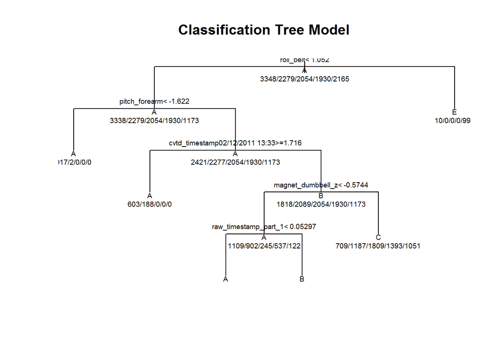

```r
plot(model_trees$finalModel, uniform = TRUE, main = "Classification Tree Model")
text(model_trees$finalModel, use.n = TRUE, all = TRUE, cex = 0.6)
```

**4. Classification trees with pca**

```r
model_tree_pca <- train(classe ~.,
                        trainPCA,
                        method = "rpart",
                        preProcess = c('center', 'scale'),
                        trControl = fitControl)
pred_tree_pca <- predict(model_tree_pca, validationPCA)
cm_tree_pca <- confusionMatrix(pred_tree_pca, validationPCA$classe)
```

```r
cm_tree_pca
```

```
## Confusion Matrix and Statistics
##
##           Reference
## Prediction    A    B    C    D    E
##          A 1116  759  684  643  721
##          B    0    0    0    0    0
##          C    0    0    0    0    0
##          D    0    0    0    0    0
##          E    0    0    0    0    0
##
## Overall Statistics
##
##                Accuracy : 0.2845
##                  95% CI : (0.2704, 0.2989)
##     No Information Rate : 0.2845
##     P-Value [Acc > NIR] : 0.506
##
##                   Kappa : 0
##  Mcnemar's Test P-Value : NA
##
## Statistics by Class:
##
##                      Class: A Class: B Class: C Class: D Class: E
## Sensitivity            1.0000   0.0000   0.0000   0.0000   0.0000
## Specificity            0.0000   1.0000   1.0000   1.0000   1.0000
## Pos Pred Value         0.2845      NaN      NaN      NaN      NaN
## Neg Pred Value            NaN   0.8065   0.8256   0.8361   0.8162
## Prevalence             0.2845   0.1935   0.1744   0.1639   0.1838
## Detection Rate         0.2845   0.0000   0.0000   0.0000   0.0000
## Detection Prevalence   1.0000   0.0000   0.0000   0.0000   0.0000
## Balanced Accuracy      0.5000   0.5000   0.5000   0.5000   0.5000
```

## PCA is even worse than classification tree.

**5. Boosting**

```r
model_boosting <- train(classe ~.,
                        train_data2,
                        method = "gbm",
                        preProcess = c('center', 'scale'),
                        verbose = FALSE,
                        trControl = fitControl)
pred_boosting <- predict(model_boosting, validation_data2)
cm_boosting <- confusionMatrix(pred_boosting, validation_data2$classe)
```

```r
cm_boosting
```

```
## Confusion Matrix and Statistics
##
##           Reference
## Prediction    A    B    C    D    E
##          A 1116    3    0    0    0
##          B    0  754    1    0    0
##          C    0    2  675    1    0
##          D    0    0    8  641    3
##          E    0    0    0    1  718
##
## Overall Statistics
##
##                Accuracy : 0.9952
##                  95% CI : (0.9924, 0.9971)
##     No Information Rate : 0.2845
##     P-Value [Acc > NIR] : < 2.2e-16
##
##                   Kappa : 0.9939
##  Mcnemar's Test P-Value : NA
##
## Statistics by Class:
##
##                      Class: A Class: B Class: C Class: D Class: E
## Sensitivity            1.0000   0.9934   0.9868   0.9969   0.9958
## Specificity            0.9989   0.9997   0.9991   0.9966   0.9997
## Pos Pred Value         0.9973   0.9987   0.9956   0.9831   0.9986
## Neg Pred Value         1.0000   0.9984   0.9972   0.9994   0.9991
## Prevalence             0.2845   0.1935   0.1744   0.1639   0.1838
## Detection Rate         0.2845   0.1922   0.1721   0.1634   0.1830
## Detection Prevalence   0.2852   0.1925   0.1728   0.1662   0.1833
## Balanced Accuracy      0.9995   0.9965   0.9930   0.9968   0.9978
```

## Boosting is the most accurate and the second fast model, my final chosen model.

# Comparing among models

collect the resampling results using [resamples] function

```r
model_list <- list(SVM = model_svm,
                   SVM_PCA = model_svm_pca,
                   CT = model_trees,
                   CT_PCA = model_tree_pca,
                   GBM = model_boosting)

resamps <- resamples(model_list)
```

look at statistical results and boxplot for each model’s accuracy

```r
summary(resamps)
```

```
##
## Call:
## summary.resamples(object = resamps)
##
## Models: SVM, SVM_PCA, CT, CT_PCA, GBM
## Number of resamples: 5
##
## Accuracy
##           Min. 1st Qu. Median   Mean 3rd Qu.   Max. NA's
## SVM     0.8076  0.8110 0.8217 0.8187  0.8247 0.8285    0
## SVM_PCA 0.7801  0.7864 0.7975 0.7925  0.7980 0.8003    0
## CT      0.3692  0.4877 0.4894 0.4878  0.5429 0.5501    0
## CT_PCA  0.2841  0.2844 0.2844 0.3344  0.2845 0.5348    0
## GBM     0.9936  0.9953 0.9962 0.9956  0.9962 0.9966    0
##
## Kappa
##           Min. 1st Qu. Median    Mean 3rd Qu.   Max. NA's
## SVM     0.7552  0.7598 0.7732 0.76950  0.7773 0.7821    0
## SVM_PCA 0.7199  0.7281 0.7422 0.73580  0.7428 0.7458    0
## CT      0.1294  0.3597 0.3615 0.33880  0.4097 0.4336    0
## CT_PCA  0.0000  0.0000 0.0000 0.08459  0.0000 0.4229    0
## GBM     0.9919  0.9941 0.9952 0.99440  0.9952 0.9957    0
```

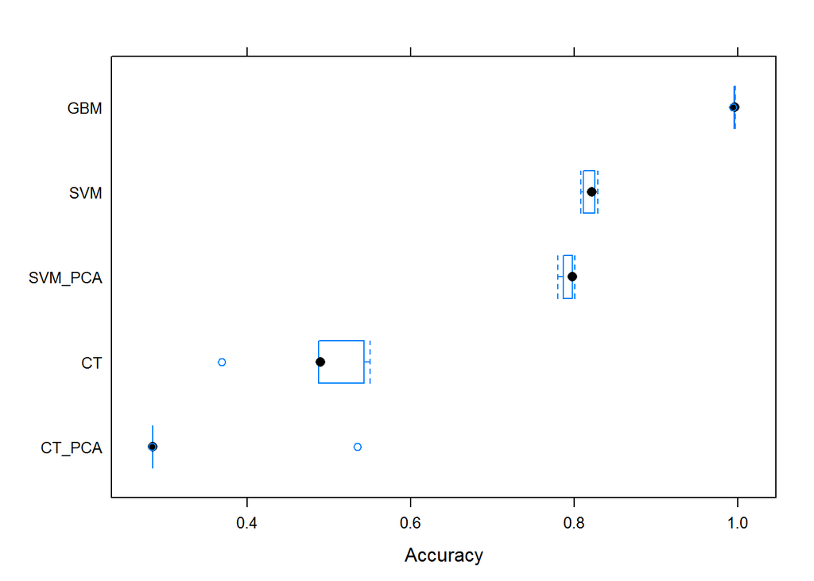

```r
bwplot(resamps, metric = "Accuracy")
```

## Boosting is the most accurate and also fast, so finally I chose boosting(GBM). And PCA didn’t improve the performance, so I did’t use PCA.

# 3. Optional: Interpreting predictors by exploring train data and measure variance importance

## Calculate Variable Importance for each model without PCA

```r
svmImp <- varImp(model_svm)
treesImp <- varImp(model_trees)
boostingImp <- varImp(model_boosting)
```

```r
F4 <- png("Figure4.png",
           width = 5*500,        # 5 x 300 pixels
           height = 5*400,
           res = 300,            # 300 pixels per inch
           pointsize = 1)
v1 <- plot(svmImp, top = 20, main = "SVM")
v2 <- plot(treesImp, top = 20, main = "Classification Tree")
v3 <- plot(boostingImp, top = 20, main = "Boosting")
# layout in specific format: svm subplot on top row, tree and boost on bottom row
grid.arrange(v1, v2, v3, layout_matrix = rbind(c(1,1), c(2,3)) )
dev.off()
```

[output not shown]

```r
print(F4)
```

## Exploring those features/predictors

boxplot of each feature vs. “classe”

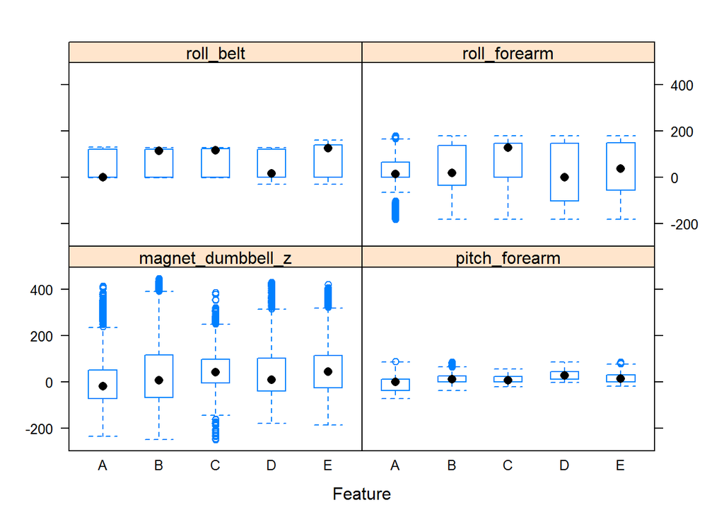

```r
featurePlot(x = train_data2[, c("pitch_forearm", "magnet_dumbbell_z", "roll_belt", "roll_forearm")],
            y = train_data2$classe, plot = "box")
```

check their correlation

```r
corr_mat2 <- abs(cor(train_data2[ , c("pitch_forearm", "magnet_dumbbell_z", "magnet_dumbbell_y",
                                      "num_window", "roll_belt", "roll_forearm",
                                      "raw_timestamp_part_1")]))
diag(corr_mat2) <- 0   # make diagnal self-correlation as 0
corr_mat2
```

```
##                      pitch_forearm magnet_dumbbell_z magnet_dumbbell_y
## pitch_forearm           0.00000000        0.17676352         0.1563469
## magnet_dumbbell_z       0.17676352        0.00000000         0.2544350
## magnet_dumbbell_y       0.15634687        0.25443498         0.0000000
## num_window              0.05059808        0.01760970         0.2389518
## roll_belt               0.17686216        0.50507220         0.2801572
## roll_forearm            0.05275270        0.04990184         0.1668354
## raw_timestamp_part_1    0.22329461        0.76307977         0.4220180
##                      num_window  roll_belt roll_forearm
## pitch_forearm        0.05059808 0.17686216   0.05275270
## magnet_dumbbell_z    0.01760970 0.50507220   0.04990184
## magnet_dumbbell_y    0.23895185 0.28015723   0.16683537
## num_window           0.00000000 0.07204168   0.01195906
## roll_belt            0.07204168 0.00000000   0.15559607
## roll_forearm         0.01195906 0.15559607   0.00000000
## raw_timestamp_part_1 0.16180610 0.37722602   0.08636508
##                      raw_timestamp_part_1
## pitch_forearm                  0.22329461
## magnet_dumbbell_z              0.76307977
## magnet_dumbbell_y              0.42201800
## num_window                     0.16180610
## roll_belt                      0.37722602
## roll_forearm                   0.08636508
## raw_timestamp_part_1           0.00000000
```

```r
# # plot correlation maps for better visualization
# corrplot(corr_mat2)
```

# 4. Evaluation on Test Set and Quiz

calculate out of sample error. First select test_data with same variables in preprocessed train_data2

```r
test_data2 <- test_data[, match_index]
```

```r
dim(test_data2)
```

```
## [1] 3923   59
```

```r
confusionMatrix(test_data2$classe, predict(model_boosting, test_data2))
```

```
## Confusion Matrix and Statistics
##
##           Reference
## Prediction    A    B    C    D    E
##          A 1116    0    0    0    0
##          B    2  756    1    0    0
##          C    0    0  680    4    0
##          D    0    0    3  639    1
##          E    0    0    0    1  720
##
## Overall Statistics
##
##                Accuracy : 0.9969
##                  95% CI : (0.9947, 0.9984)
##     No Information Rate : 0.285
##     P-Value [Acc > NIR] : < 2.2e-16
##
##                   Kappa : 0.9961
##  Mcnemar's Test P-Value : NA
##
## Statistics by Class:
##
##                      Class: A Class: B Class: C Class: D Class: E
## Sensitivity            0.9982   1.0000   0.9942   0.9922   0.9986
## Specificity            1.0000   0.9991   0.9988   0.9988   0.9997
## Pos Pred Value         1.0000   0.9960   0.9942   0.9938   0.9986
## Neg Pred Value         0.9993   1.0000   0.9988   0.9985   0.9997
## Prevalence             0.2850   0.1927   0.1744   0.1642   0.1838
## Detection Rate         0.2845   0.1927   0.1733   0.1629   0.1835
## Detection Prevalence   0.2845   0.1935   0.1744   0.1639   0.1838
## Balanced Accuracy      0.9991   0.9995   0.9965   0.9955   0.9992
```